# CMPINF 2130 Summer 2021 - Week 06

continue with continuous variables

Dr. Joseph P. Yurko

6/21/2021

## load packages

```r
library(tidyverse)
```

## Synthetic data

```r
set.seed(2130)

x <- rnorm(n = 5000)

xdf <- tibble::tibble(x = x)

xdf %>% glimpse()
```

```
## Rows: 5,000
## Columns: 1
## $ x <dbl> 0.48985558, 0.27478193, 0.05470678, -0.17662471, -0.92091499, -0.240~
```

Histogram

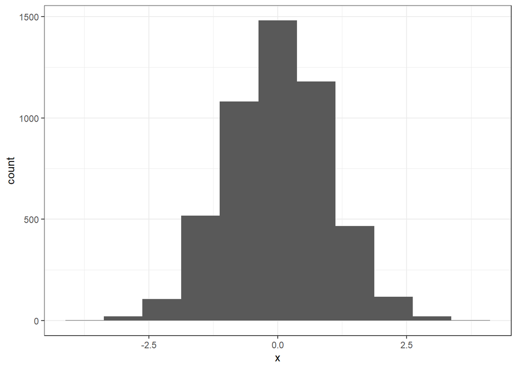

```r
xdf %>%
  ggplot(mapping = aes(x = x)) +
  geom_histogram(bins = 11) +
  theme_bw()
```

Histogram with a kernel density estimate (kde) plot.

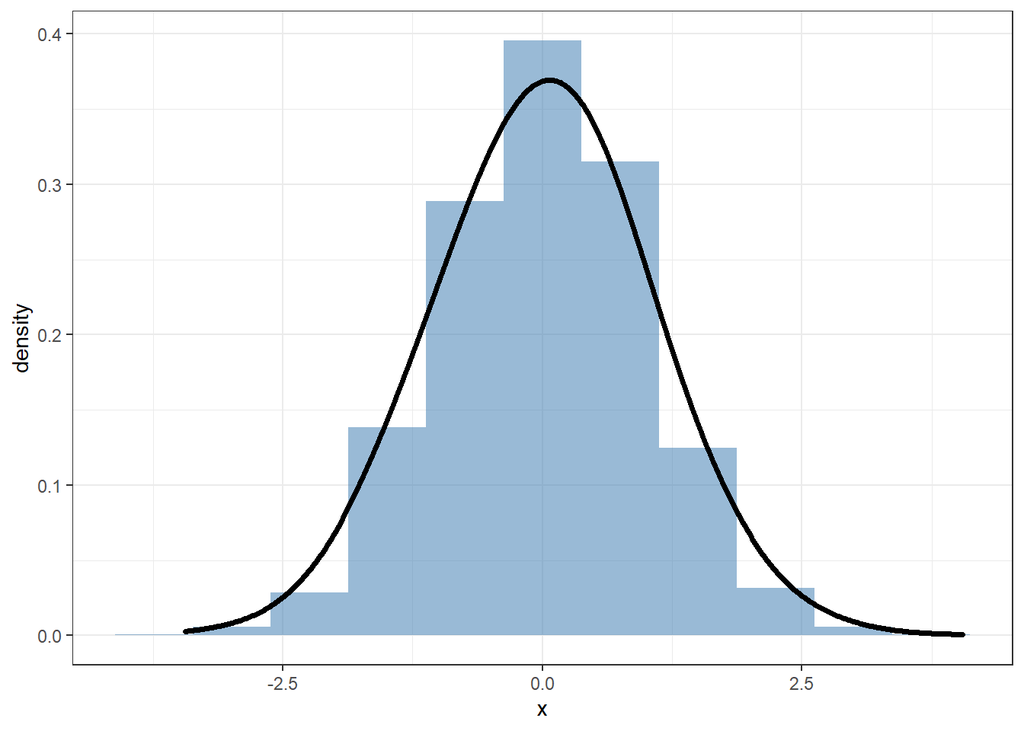

```r
xdf %>%
  ggplot(mapping = aes(x = x)) +
  geom_histogram(bins = 11,
                 mapping = aes(y = stat(density)),
                 fill = 'steelblue', alpha = 0.55) +
  geom_density(size = 1.25, adjust = 3) +
  theme_bw()
```

Alternatively, instead of using “bars” or filled-in-areas for the histogram we could use the **frequency polygon**.

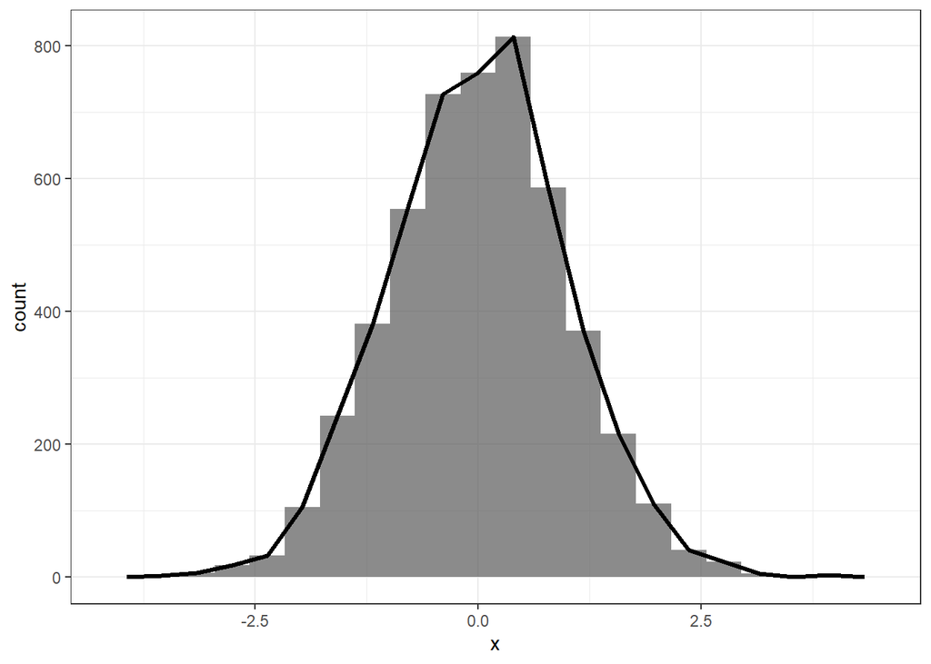

```r
xdf %>%
  ggplot(mapping = aes(x = x)) +
  geom_histogram(bins = 20,
                 alpha = 0.7) +
  geom_freqpoly(bins = 20,
                size = 1.2) +
  theme_bw()
```

Overlay a histogram, frequency polygon, and kernel density estimate.

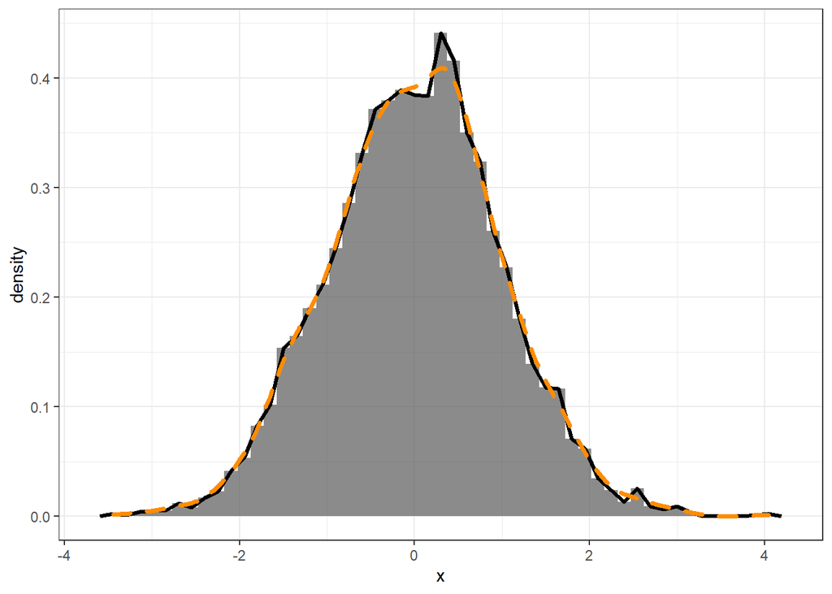

```r
xdf %>%
  ggplot(mapping = aes(x = x)) +
  geom_histogram(bins = 51,
                 alpha = 0.7,
                 mapping = aes(y = stat(density))) +
  geom_freqpoly(bins = 51,
                size = 1.2,
                mapping = aes(y = stat(density))) +
  geom_density(size = 1.25, linetype = 'dashed',
               color = 'darkorange') +
  theme_bw()
```

To include the observations with a histogram is via a **rug plot**. Let’s first look at the rug by itself.

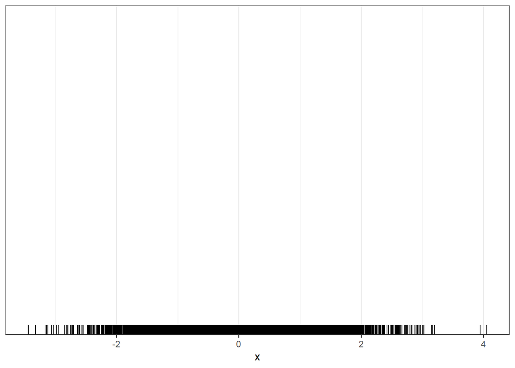

```r
xdf %>%
  ggplot(mapping = aes(x = x)) +
  geom_rug() +
  theme_bw()
```

Can be useful to set the transparency so we can see the difference between low and high density regions more clearly.

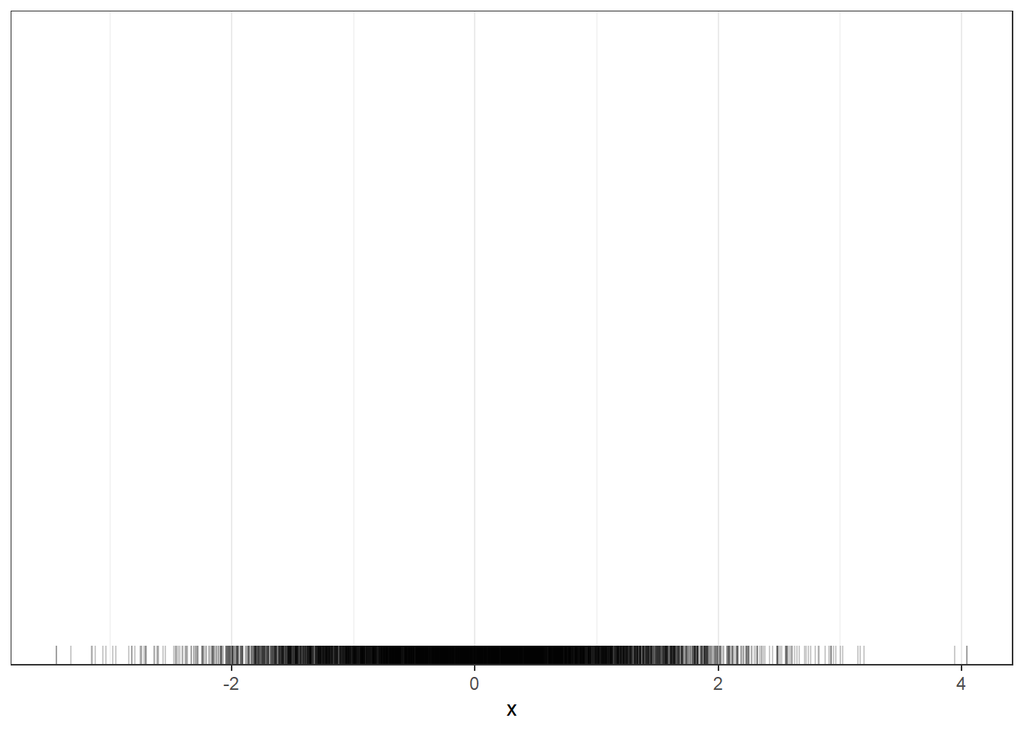

```r
xdf %>%
  ggplot(mapping = aes(x = x)) +
  geom_rug(alpha = 0.2) +
  theme_bw()
```

Add in a histogram to provide additional context to the distributional shape.

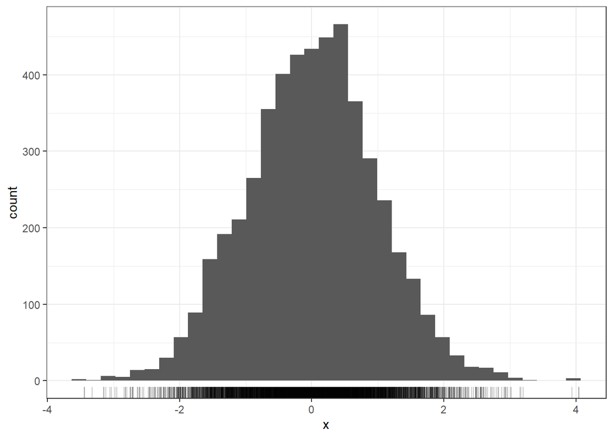

```r
xdf %>%
  ggplot(mapping = aes(x = x)) +
  geom_rug(alpha = 0.2) +
  geom_histogram(bins = 35) +
  theme_bw()
```

One benefit of a rug + histogram is when we have relatively few bins and relatively few data points.

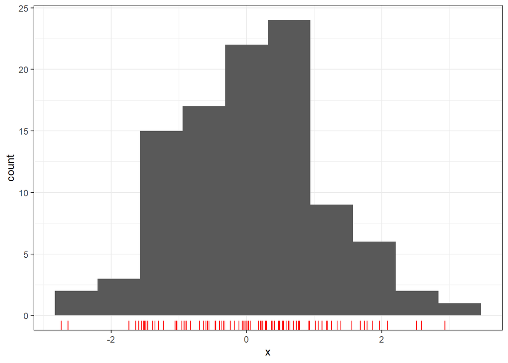

```r
xdf %>%
  slice(1:101) %>%
  ggplot(mapping = aes(x = x)) +
  geom_rug(color = 'red') +
  geom_histogram(bins = 10) +
  theme_bw()
```

The rug can help interpret the eCDF plot as well.

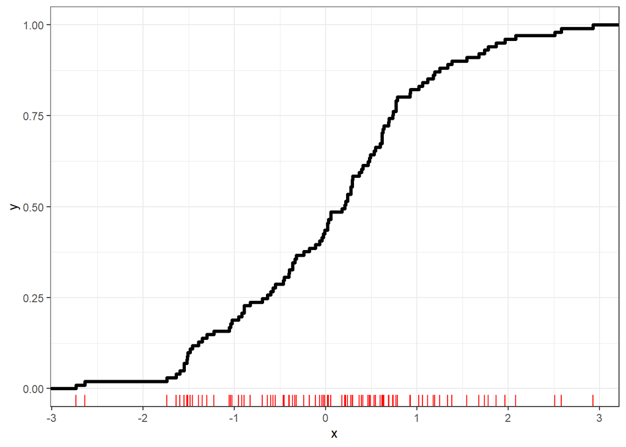

```r
xdf %>%
  slice(1:101) %>%
  ggplot(mapping = aes(x = x)) +
  geom_rug(color = 'red') +
  stat_ecdf(size = 1.25) +
  theme_bw()
```

## mpg data

```r
mpg %>% glimpse()
```

```
## Rows: 234
## Columns: 11
## $ manufacturer <chr> "audi", "audi", "audi", "audi", "audi", "audi", "audi", "~
## $ model        <chr> "a4", "a4", "a4", "a4", "a4", "a4", "a4", "a4 quattro", "~
## $ displ        <dbl> 1.8, 1.8, 2.0, 2.0, 2.8, 2.8, 3.1, 1.8, 1.8, 2.0, 2.0, 2.~
## $ year         <int> 1999, 1999, 2008, 2008, 1999, 1999, 2008, 1999, 1999, 200~
## $ cyl          <int> 4, 4, 4, 4, 6, 6, 6, 4, 4, 4, 4, 6, 6, 6, 6, 6, 6, 8, 8, ~
## $ trans        <chr> "auto(l5)", "manual(m5)", "manual(m6)", "auto(av)", "auto~
## $ drv          <chr> "f", "f", "f", "f", "f", "f", "f", "4", "4", "4", "4", "4~
## $ cty          <int> 18, 21, 20, 21, 16, 18, 18, 18, 16, 20, 19, 15, 17, 17, 1~
## $ hwy          <int> 29, 29, 31, 30, 26, 26, 27, 26, 25, 28, 27, 25, 25, 25, 2~
## $ fl           <chr> "p", "p", "p", "p", "p", "p", "p", "p", "p", "p", "p", "p~
## $ class        <chr> "compact", "compact", "compact", "compact", "compact", "c~
```

Visualize the distribution of `hwy` with a histogram and let’s include the rug.

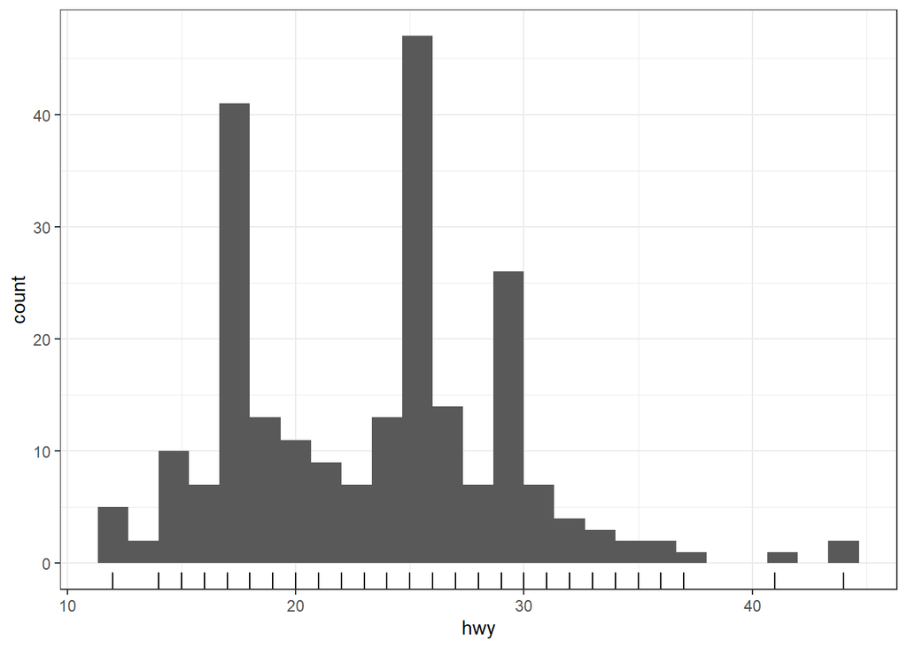

```r
mpg %>%
  ggplot(mapping = aes(x = hwy)) +
  geom_rug() +
  geom_histogram(bins = 25) +
  theme_bw()
```

Can use binwidth instead.

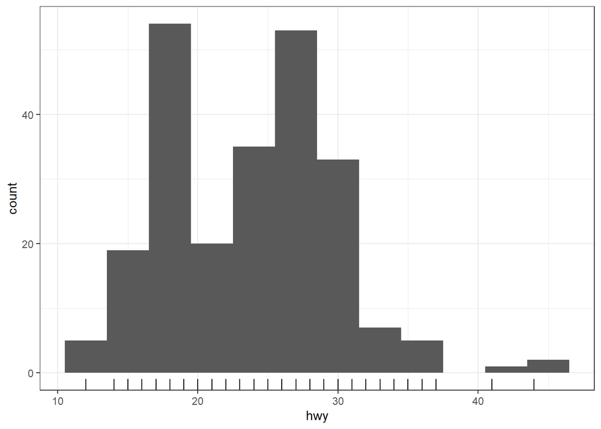

```r
mpg %>%
  ggplot(mapping = aes(x = hwy)) +
  geom_rug() +
  geom_histogram(binwidth = 3) +
  theme_bw()
```

One way to check the number of unique values, is with the `count()`.

```r
mpg %>% count(hwy)
```

```
## # A tibble: 27 x 2
##      hwy     n
##    <int> <int>
##  1    12     5
##  2    14     2
##  3    15    10
##  4    16     7
##  5    17    31
##  6    18    10
##  7    19    13
##  8    20    11
##  9    21     2
## 10    22     7
## # ... with 17 more rows
```

Alternatively we could use the `distinct()` function to only get the unique values.

```r
mpg %>% distinct(hwy)
```

```
## # A tibble: 27 x 1
##      hwy
##    <int>
##  1    29
##  2    31
##  3    30
##  4    26
##  5    27
##  6    25
##  7    28
##  8    24
##  9    23
## 10    20
## # ... with 17 more rows
```

Use the base R `unique()` function.

```r
unique( mpg$hwy )
```

```
##  [1] 29 31 30 26 27 25 28 24 23 20 15 17 19 14 22 21 18 12 16 33 32 34 36 35 37
## [26] 44 41
```

Can wrap `length()` around `unique()` to get the number of unique.

```r
length( unique( mpg$hwy ) )
```

```
## [1] 27
```

The tidy way of executing these steps:

```r
mpg %>% select(hwy) %>% pull() %>% unique() %>% length()
```

```
## [1] 27
```

`n_distinct()` function is a wrapper to `length( unique(x) )`.

```r
mpg %>% pull(hwy) %>% n_distinct()
```

```
## [1] 27
```

We want to use a for-loop to iterate over every column in `mpg` and apply the `n_distinct()` function to each column.

```r
for( vname in names(mpg) )
{
  mpg %>% select(all_of(vname)) %>%
    pull() %>%
    n_distinct() %>%
    print()
}
```

```
## [1] 15
## [1] 38
## [1] 35
## [1] 2
## [1] 4
## [1] 10
## [1] 3
## [1] 21
## [1] 27
## [1] 5
## [1] 7
```

Let’s assign the result to an element in a list. We must first create a list that contains missing or NULL values.

```r
list_nunique <- vector( mode = 'list', length = ncol(mpg) )

list_nunique
```

[output not shown]

Assign the names of the elements of the list as the names of the columns.

```r
names( list_nunique ) <- names(mpg)

list_nunique
```

[output not shown]

We can assign the result of `n_distinct()` to each element in the list.

```r
for( vname in names(list_nunique) )
{
  list_nunique[[vname]] <- mpg %>%
    select(all_of(vname)) %>%
    pull() %>%
    n_distinct()
}
```

Check.

```r
list_nunique
```

```
## $manufacturer
## [1] 15
##
## $model
## [1] 38
##
## $displ
## [1] 35
##
## $year
## [1] 2
##
## $cyl
## [1] 4
##
## $trans
## [1] 10
##
## $drv
## [1] 3
##
## $cty
## [1] 21
##
## $hwy
## [1] 27
##
## $fl
## [1] 5
##
## $class
## [1] 7
```

R is more **functional programming** compared to Python. We want to iterate over the elements of the object – the columns in our dataframe.

Base R has a family of “apply” functions. I don’t use the base R unless I have to.

`tidyverse` has the `purrr` package to handle “mapping” a function to every element in an object.

```r
purrr::map( mpg, n_distinct )
```

```
## $manufacturer
## [1] 15
##
## $model
## [1] 38
##
## $displ
## [1] 35
##
## $year
## [1] 2
##
## $cyl
## [1] 4
##
## $trans
## [1] 10
##
## $drv
## [1] 3
##
## $cty
## [1] 21
##
## $hwy
## [1] 27
##
## $fl
## [1] 5
##
## $class
## [1] 7
```

The `purrr::map()` function returns a list.

```r
purrr::map( mpg, n_distinct ) %>% class()
```

```
## [1] "list"
```

We can use the `map_*` functions to specify the data type of returned object.

```r
mpg %>% purrr::map_dbl(n_distinct)
```

```
## manufacturer        model        displ         year          cyl        trans
##           15           38           35            2            4           10
##          drv          cty          hwy           fl        class
##            3           21           27            5            7
```

We could return a character vector.

```r
mpg %>% purrr::map_chr(n_distinct)
```

```
## manufacturer        model        displ         year          cyl        trans
##         "15"         "38"         "35"          "2"          "4"         "10"
##          drv          cty          hwy           fl        class
##          "3"         "21"         "27"          "5"          "7"
```

Return a data.frame with `map_dfc()`.

```r
mpg %>% purrr::map_dfc(n_distinct)
```

```
## # A tibble: 1 x 11
##   manufacturer model displ  year   cyl trans   drv   cty   hwy    fl class
##          <int> <int> <int> <int> <int> <int> <int> <int> <int> <int> <int>
## 1           15    38    35     2     4    10     3    21    27     5     7
```

To calculate the number of missing values, we can use two functions:

```r
mpg %>%
  select(hwy) %>%
  pull() %>%
  is.na() %>%
  sum()
```

```
## [1] 0
```

The “conventional function approach”:

```r
sum(is.na( mpg$hwy) )
```

```
## [1] 0
```

Use `purrr` to functionally iterate over every column and apply `sum(is.na())`.

```r
mpg %>%
  purrr::map_dbl( ~sum(is.na(.)) )
```

```
## manufacturer        model        displ         year          cyl        trans
##            0            0            0            0            0            0
##          drv          cty          hwy           fl        class
##            0            0            0            0            0
```

Let’s define our own sum function.

```r
my_sumisna <- function(x)
{
  sum( is.na(x) )
}
```

```r
mpg %>% purrr::map_dbl( my_sumisna )
```

```
## manufacturer        model        displ         year          cyl        trans
##            0            0            0            0            0            0
##          drv          cty          hwy           fl        class
##            0            0            0            0            0
```

`purrr` has useful helper functions for selecting columns by data types.

To **keep** only numeric columns:

```r
mpg %>%
  purrr::keep(is.numeric) %>%
  names()
```

```
## [1] "displ" "year"  "cyl"   "cty"   "hwy"
```

To keep all-except numerics or to **discard** numeric columns:

```r
mpg %>%
  purrr::discard(is.numeric) %>%
  names()
```

```
## [1] "manufacturer" "model"        "trans"        "drv"          "fl"
## [6] "class"
```

To check the data type per column.

```r
mpg %>% purrr::map_chr( class )
```

```
## manufacturer        model        displ         year          cyl        trans
##  "character"  "character"    "numeric"    "integer"    "integer"  "character"
##          drv          cty          hwy           fl        class
##  "character"    "integer"    "integer"  "character"  "character"
```

Date time data types can mess up the above line of code.

```r
mpg %>% purrr::map( class )
```

```
## $manufacturer
## [1] "character"
##
## $model
## [1] "character"
##
## $displ
## [1] "numeric"
##
## $year
## [1] "integer"
##
## $cyl
## [1] "integer"
##
## $trans
## [1] "character"
##
## $drv
## [1] "character"
##
## $cty
## [1] "integer"
##
## $hwy
## [1] "integer"
##
## $fl
## [1] "character"
##
## $class
## [1] "character"
```

## Continuous grouped by a categorical

Or, **condition** a continuous variable on a categorical variable. How does a continuous variable “behave” for different levels of a categorical variable?

Let’s look at the distribution for `hwy` again.

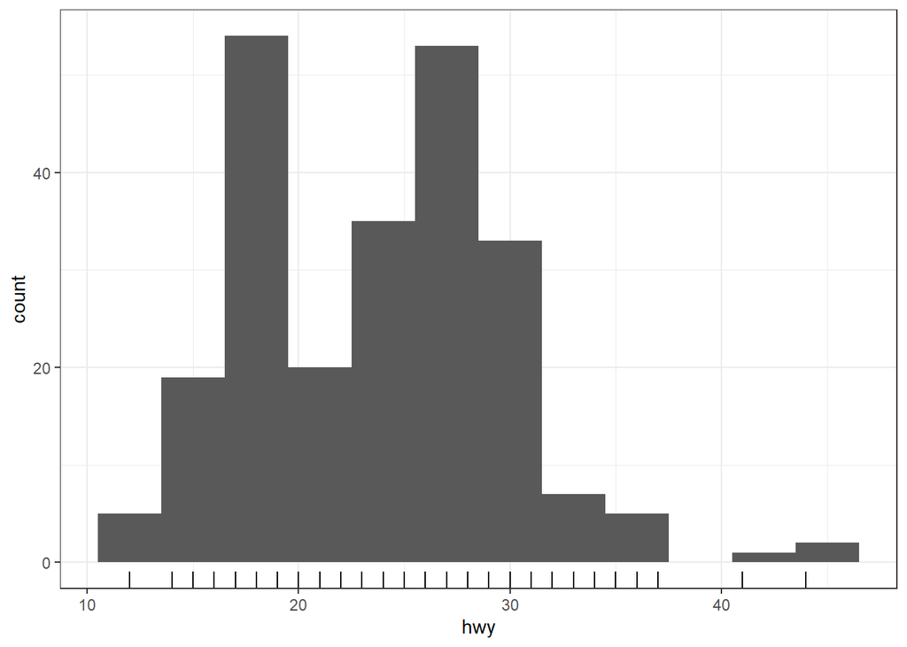

```r
mpg %>%
  ggplot(mapping = aes(x = hwy)) +
  geom_rug() +
  geom_histogram(binwidth = 3) +
  theme_bw()
```

Does the distribution of `hwy` change, based on `drv`? We can study this question graphically via aesthetics of the histogram.

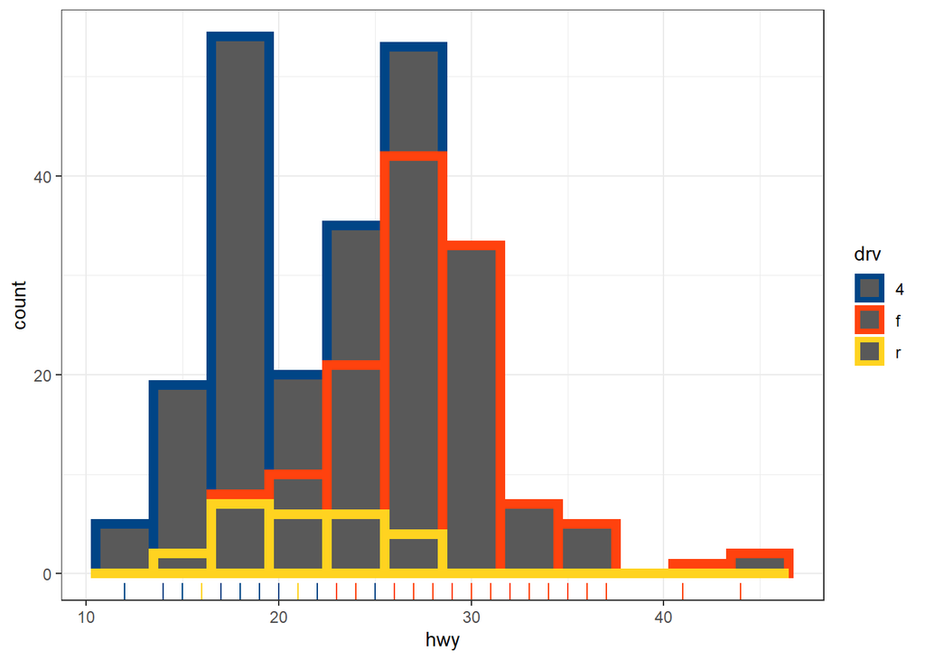

```r
mpg %>%
  ggplot(mapping = aes(x = hwy)) +
  geom_rug(mapping = aes(color = drv)) +
  geom_histogram(mapping = aes(color = drv),
                 binwidth = 3,
                 size = 2.5) +
  ggthemes::scale_color_calc() +
  theme_bw()
```

Usually we map the `fill` of a histogram to a categorical variable.

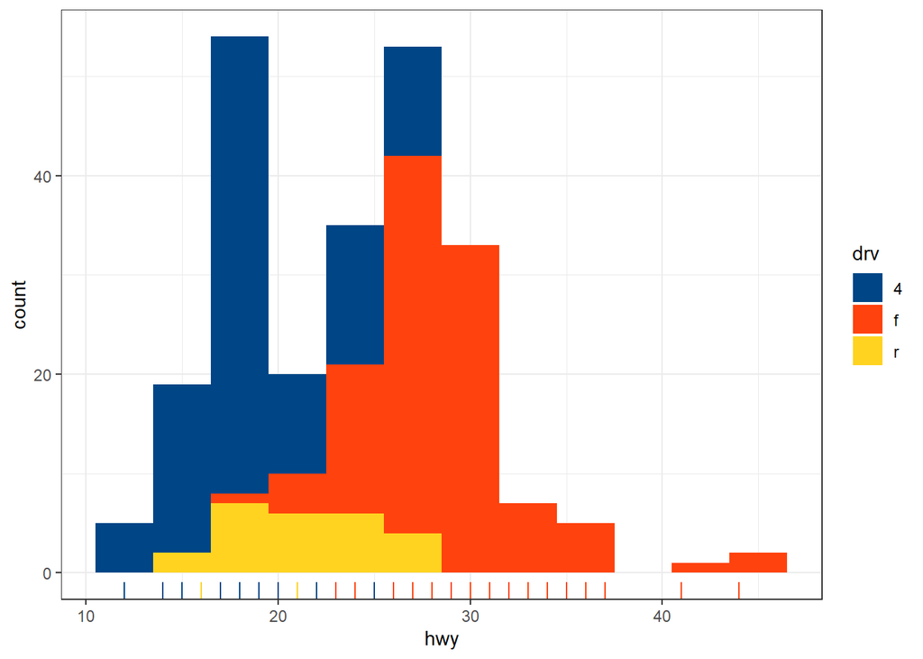

```r
mpg %>%
  ggplot(mapping = aes(x = hwy)) +
  geom_rug(mapping = aes(color = drv)) +
  geom_histogram(mapping = aes(fill = drv),
                 binwidth = 3) +
  ggthemes::scale_color_calc() +
  ggthemes::scale_fill_calc() +
  theme_bw()
```

We can “dodge” the histogram bars when there is overlap.

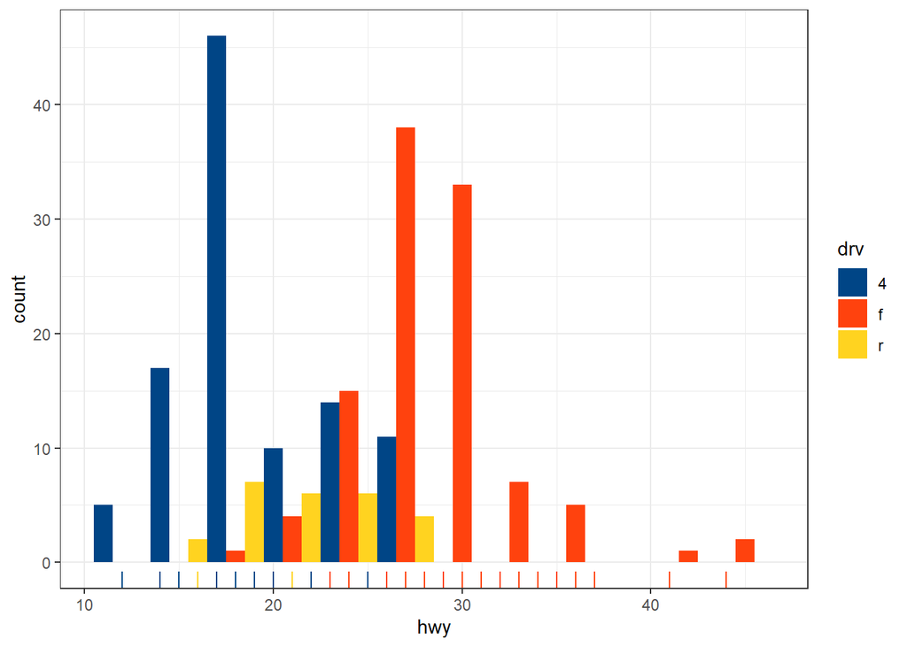

```r
mpg %>%
  ggplot(mapping = aes(x = hwy)) +
  geom_rug(mapping = aes(color = drv)) +
  geom_histogram(mapping = aes(fill = drv),
                 binwidth = 3,
                 position = 'dodge') +
  ggthemes::scale_color_calc() +
  ggthemes::scale_fill_calc() +
  theme_bw()
```

Instead I prefer to use the `geom_freqpoly()` to handle multiple histograms at once.

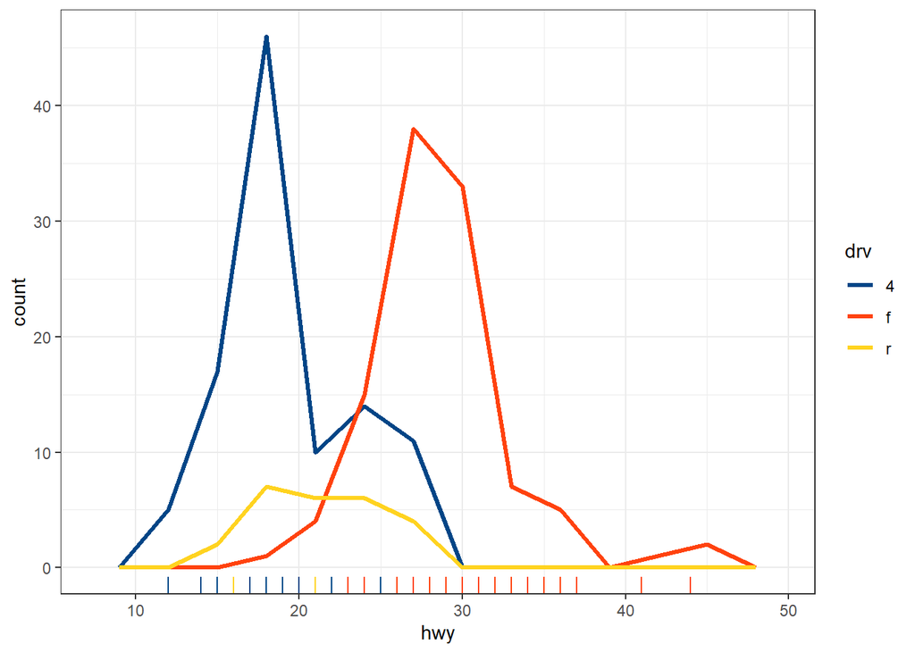

```r
mpg %>%
  ggplot(mapping = aes(x = hwy)) +
  geom_rug(mapping = aes(color = drv)) +
  geom_freqpoly(mapping = aes(color = drv),
                binwidth = 3,
                size = 1.15) +
  ggthemes::scale_color_calc() +
  theme_bw()
```

We have very different *sample sizes* across the groups.

```r
mpg %>% count(drv)
```

```
## # A tibble: 3 x 2
##   drv       n
##   <chr> <int>
## 1 4       103
## 2 f       106
## 3 r        25
```

Use the density stat to compare histograms when the sample sizes are different across groups.

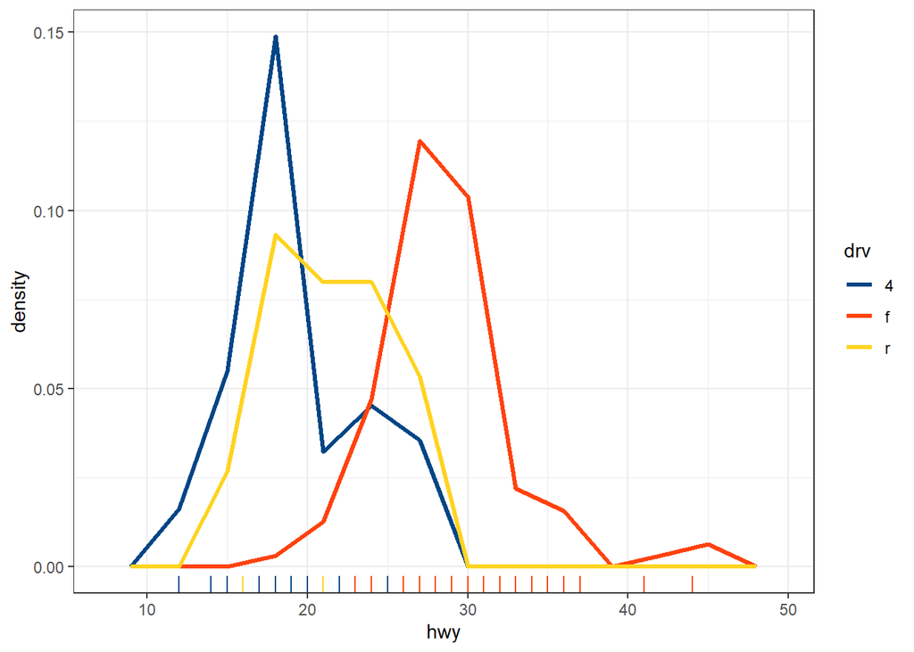

```r
mpg %>%
  ggplot(mapping = aes(x = hwy)) +
  geom_rug(mapping = aes(color = drv)) +
  geom_freqpoly(mapping = aes(color = drv,
                              y = stat(density)),
                binwidth = 3,
                size = 1.15) +
  ggthemes::scale_color_calc() +
  theme_bw()
```

We had an original “ungrouped” distribution and we can compare that shape to the grouped or **conditional** distributions.

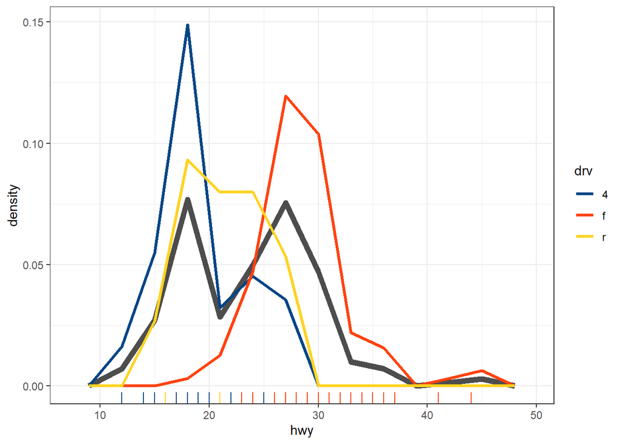

```r
mpg %>%
  ggplot(mapping = aes(x = hwy)) +
  geom_rug(mapping = aes(color = drv)) +
  geom_freqpoly(mapping = aes(y = stat(density)),
                color = 'black', size = 2.25, alpha = 0.7,
                binwidth = 3) +
  geom_freqpoly(mapping = aes(color = drv,
                              y = stat(density)),
                binwidth = 3,
                size = 1.15) +
  ggthemes::scale_color_calc() +
  theme_bw()
```

Alternatively, we can use kernel density estimate.

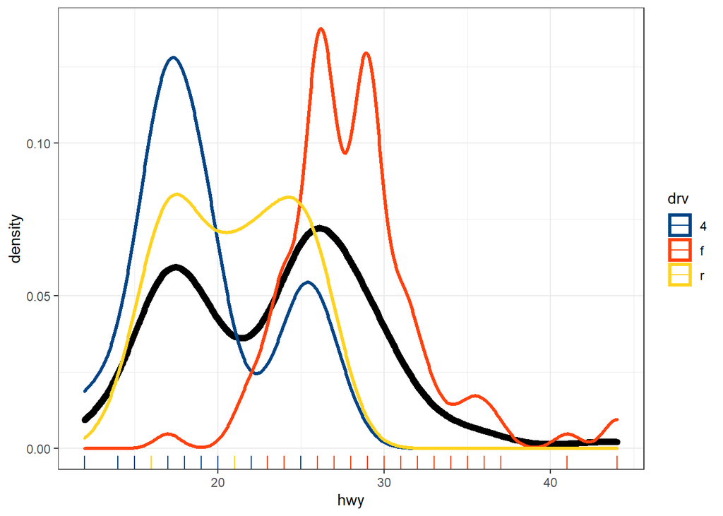

```r
mpg %>%
  ggplot(mapping = aes(x = hwy)) +
  geom_rug(mapping = aes(color = drv)) +
  geom_density(color = 'black', size = 2.25, alpha = 0.7) +
  geom_density(mapping = aes(color = drv),
               size = 1.1) +
  ggthemes::scale_color_calc() +
  theme_bw()
```

We can reach the same conclusion by working the eCDF. Let’s first look at the eCDF of `hwy`.

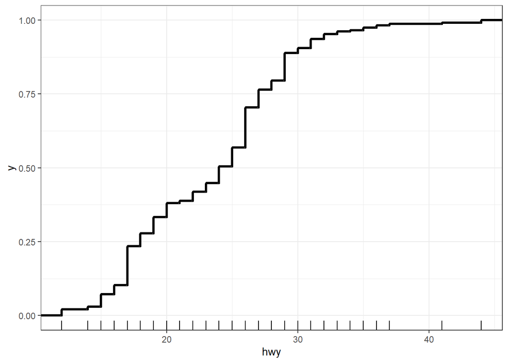

```r
mpg %>%
  ggplot(mapping = aes(x = hwy)) +
  geom_rug() +
  stat_ecdf(size = 1.2) +
  theme_bw()
```

“Break up”, “drill down”, or **condition** the `hwy` eCDF on the value of `drv`.

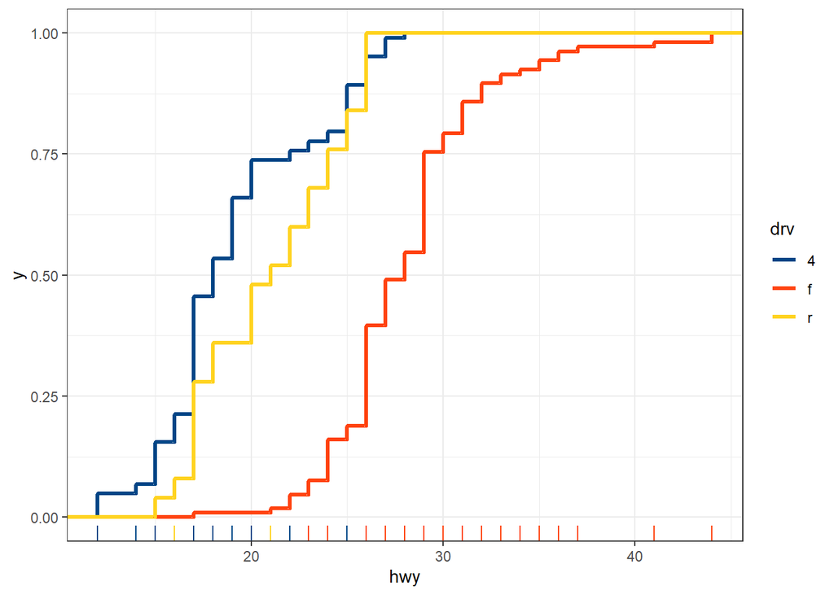

```r
mpg %>%
  ggplot(mapping = aes(x = hwy)) +
  geom_rug(mapping = aes(color = drv)) +
  stat_ecdf(size = 1.2,
            mapping = aes(color = drv)) +
  ggthemes::scale_color_calc() +
  theme_bw()
```

Include the marginal CDF as well.

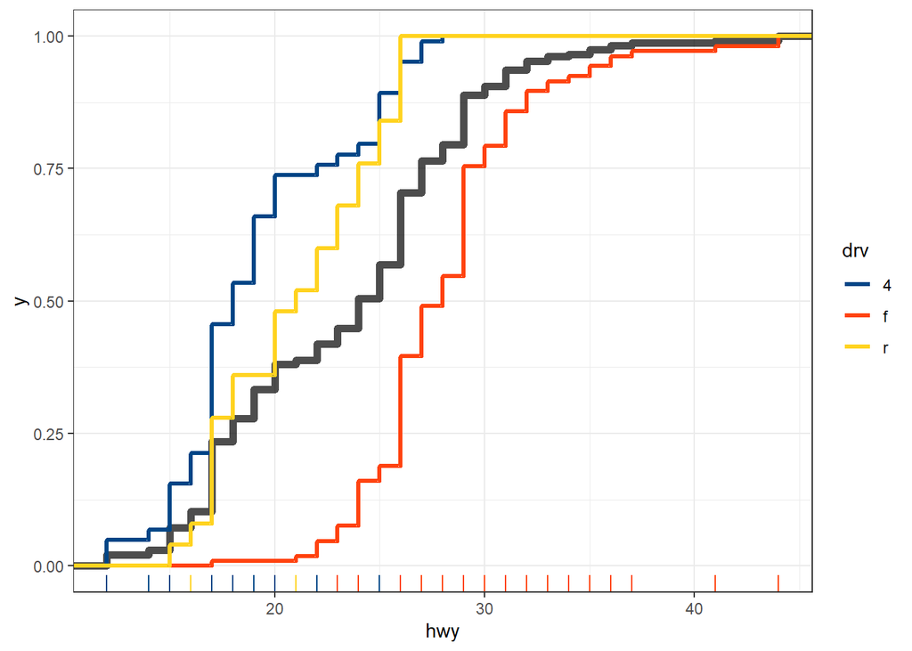

```r
mpg %>%
  ggplot(mapping = aes(x = hwy)) +
  geom_rug(mapping = aes(color = drv)) +
  stat_ecdf(color = 'black', size = 2, alpha = 0.7) +
  stat_ecdf(size = 1.2,
            mapping = aes(color = drv)) +
  ggthemes::scale_color_calc() +
  theme_bw()
```

We can directly compare **quantiles** across the conditional groups.

For example, to compare the median values.

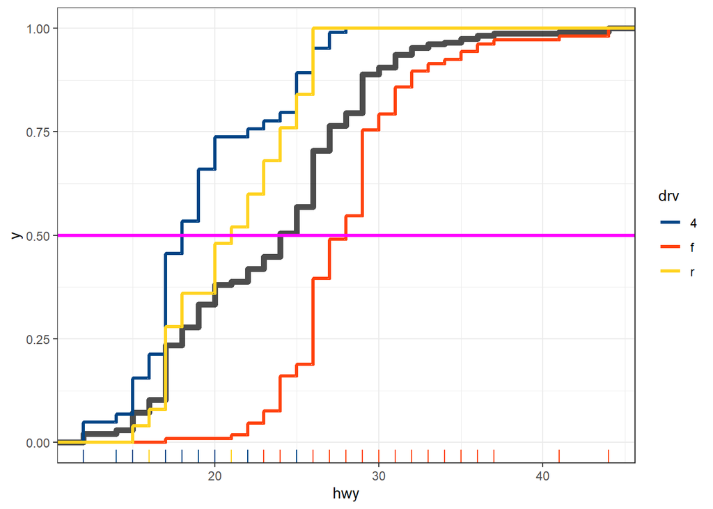

```r
mpg %>%
  ggplot(mapping = aes(x = hwy)) +
  geom_rug(mapping = aes(color = drv)) +
  stat_ecdf(color = 'black', size = 2, alpha = 0.7) +
  stat_ecdf(size = 1.2,
            mapping = aes(color = drv)) +
  geom_hline(yintercept = 0.5,
             color = 'magenta', size = 1.1) +
  ggthemes::scale_color_calc() +
  theme_bw()
```

Or the 75th quantile.

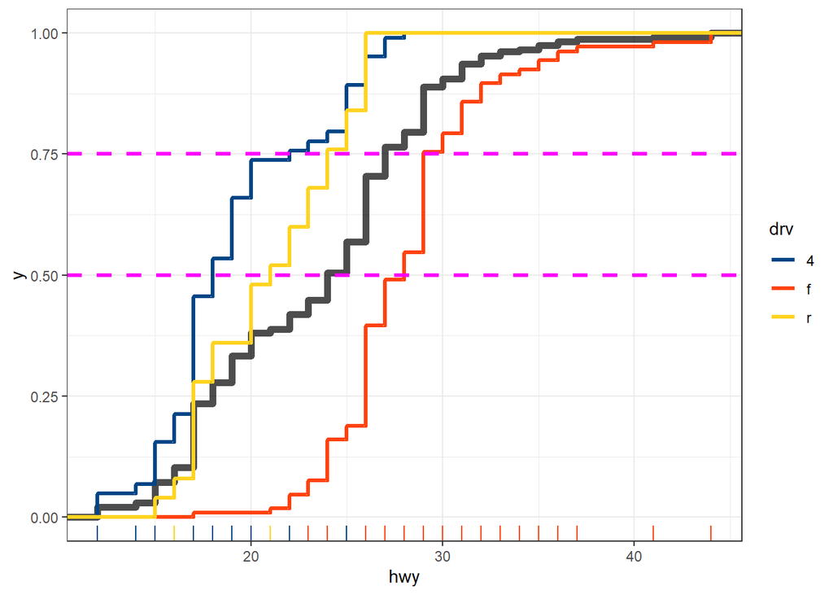

```r
mpg %>%
  ggplot(mapping = aes(x = hwy)) +
  geom_rug(mapping = aes(color = drv)) +
  stat_ecdf(color = 'black', size = 2, alpha = 0.7) +
  stat_ecdf(size = 1.2,
            mapping = aes(color = drv)) +
  geom_hline(yintercept = c(0.5, 0.75),
             linetype = 'dashed',
             color = 'magenta', size = 1.1) +
  ggthemes::scale_color_calc() +
  theme_bw()
```

Useful to consider the 25th, median, and 75th quantiles.

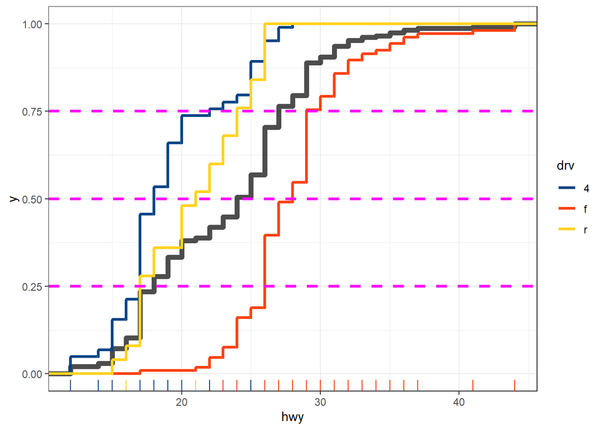

```r
mpg %>%
  ggplot(mapping = aes(x = hwy)) +
  geom_rug(mapping = aes(color = drv)) +
  stat_ecdf(color = 'black', size = 2, alpha = 0.7) +
  stat_ecdf(size = 1.2,
            mapping = aes(color = drv)) +
  geom_hline(yintercept = c(0.25, 0.5, 0.75),
             linetype = 'dashed',
             color = 'magenta', size = 1.1) +
  ggthemes::scale_color_calc() +
  theme_bw()
```

## Quantiles and Boxplots

We can compute them with a `group_by()` and `summarize()` pipepline.

```r
mpg %>%
  group_by(drv) %>%
  summarise(num_rows = n(),
            q25_hwy = quantile(hwy, 0.25),
            q50_hwy = median(hwy),
            q75_hwy = quantile(hwy, 0.75)) %>%
  ungroup()
```

```
## # A tibble: 3 x 5
##   drv   num_rows q25_hwy q50_hwy q75_hwy
##   <chr>    <int>   <dbl>   <dbl>   <dbl>
## 1 4          103      17      18      22
## 2 f          106      26      28      29
## 3 r           25      17      21      24
```

The box of a boxplot denotes the 25th, median, and 75th quantiles.

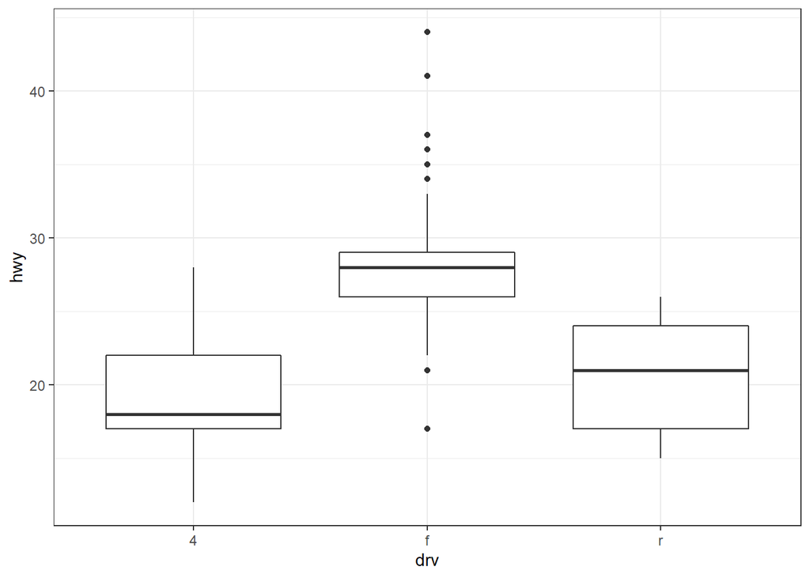

```r
mpg %>%
  ggplot(mapping = aes(x = drv, y = hwy)) +
  geom_boxplot() +
  theme_bw()
```

The R4DS book describes the boxplot [here](https://r4ds.had.co.nz/exploratory-data-analysis.html#cat-cont).

A downside of the basic boxplot is we don’t have an idea of the sample size. A useful convention is to have the width of the box vary by the sample size per group.

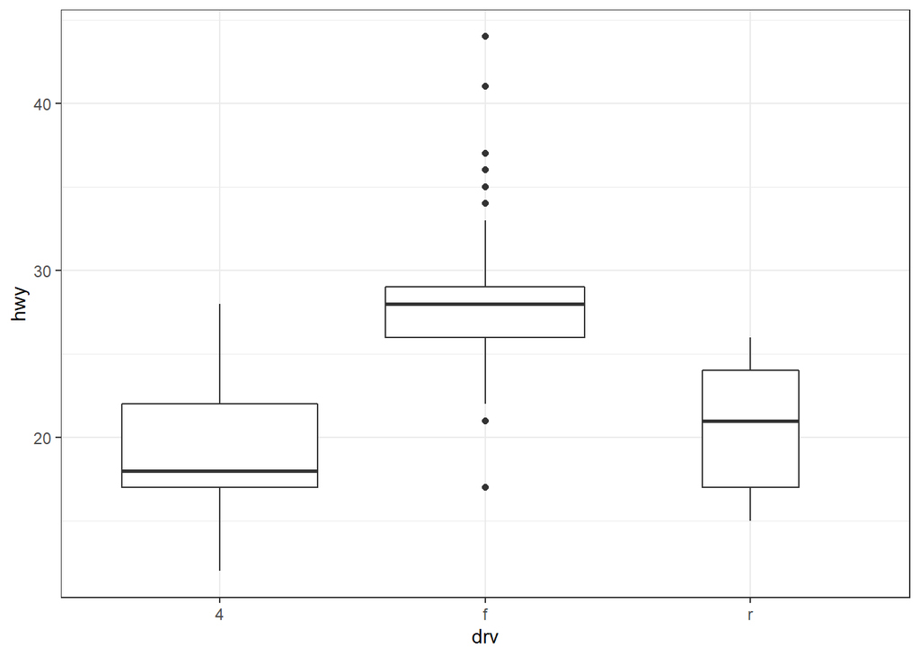

```r
mpg %>%
  ggplot(mapping = aes(x = drv, y = hwy)) +
  geom_boxplot(varwidth = TRUE) +
  theme_bw()
```

Reorder the levels.

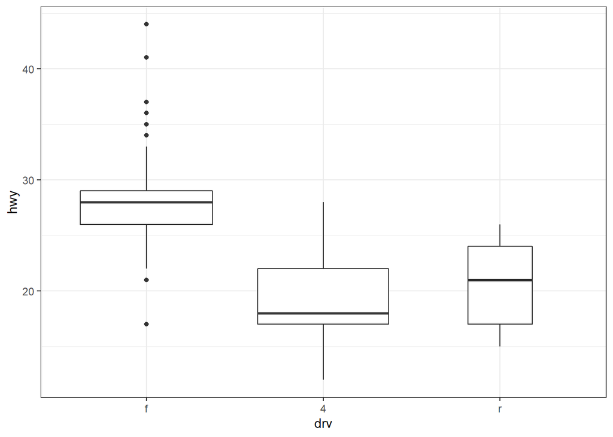

```r
mpg %>%
  mutate(drv = forcats::fct_infreq(drv)) %>%
  ggplot(mapping = aes(x = drv, y = hwy)) +
  geom_boxplot(varwidth = TRUE) +
  theme_bw()
```

But we can include an additional grouping variable via other aesthetics of the boxplot.

```r
mpg %>% count(drv, cyl)
```

```
## # A tibble: 9 x 3
##   drv     cyl     n
##   <chr> <int> <int>
## 1 4         4    23
## 2 4         6    32
## 3 4         8    48
## 4 f         4    58
## 5 f         5     4
## 6 f         6    43
## 7 f         8     1
## 8 r         6     4
## 9 r         8    21
```

Map the `cyl` to the `fill` and `color` of the boxplot.

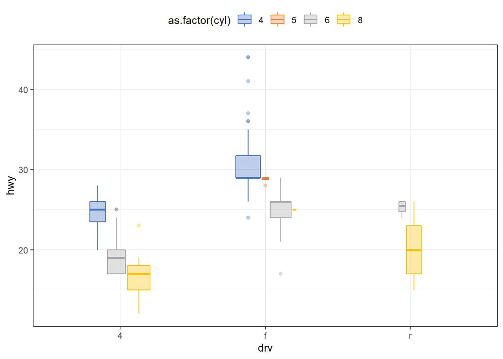

```r
mpg %>%
  ggplot(mapping = aes(x = drv, y = hwy)) +
  geom_boxplot(mapping = aes(fill = as.factor(cyl),
                             color = as.factor(cyl)),
               alpha = 0.35,
               varwidth = TRUE) +
  ggthemes::scale_color_excel_new() +
  ggthemes::scale_fill_excel_new() +
  theme_bw() +
  theme(legend.position = "top")
```

The more you drill down the smaller the sample sizes become…

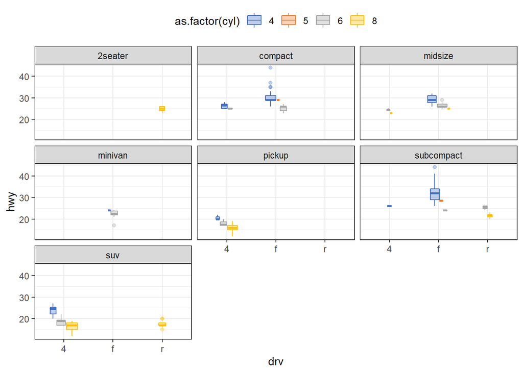

```r
mpg %>%
  ggplot(mapping = aes(x = drv, y = hwy)) +
  geom_boxplot(mapping = aes(fill = as.factor(cyl),
                             color = as.factor(cyl)),
               alpha = 0.35,
               varwidth = TRUE) +
  facet_wrap(~class) +
  ggthemes::scale_color_excel_new() +
  ggthemes::scale_fill_excel_new() +
  theme_bw() +
  theme(legend.position = "top")
```

The boxplot does not tell us **anything** about the shape of the distribution.